# Analysis of Large Wildland Fires in California, Nevada, and Idaho

Li Jia Go, Melissa Merritt, and Nanditha Satagopan

2022-12-14

## Git Repository: https://github.com/lijiago/EDAProject_Go_Merritt_Satagopan

## Tables and Figures

**Table 1**: Summary of Data Structure

**Figure 1**: Figure showing histogram of large wildfires in 1988 and 2000, California

**Figure 2**: Map of location of large wildfires in California in 1988 and 2000

**Figure 7**: Burnt Wildland Use Fire Area from 1988-2007 in California

**Figure 8**: Pairwise Relationships between Mean Fire Sizes in California, Idaho, and Nevada

**Figure 9**: Time Series Analysis Plot of Wildfire Area from 1988-2007 in California

# Rationale and Research Questions

With climate change, recent observations show an increase in occurrences, severity and extent of wildfires across the United States. As disturbance regimes across the country change, we thought it was important to assess trends, differences, and changes in specific fire regimes. The analysis is aimed at trying to infer any potential differences and trends in the sizes and occurrences of large wildfires through the last few decades. Monitoring any trend in the large fires can help gain an understanding on the health of the landscape and perhaps predicting future incidents. The use of prescribed and wildland fires through the years also gives us an understanding of how they have gained popularity in landscape management over time.

We decided to identify and focus our study on the three states with the most large fire occurrences (California, Idaho, and Nevada) because that would provide us with a larger dataset and better accuracy to derive conclusions.

**Research Questions:**

**Question 1:** Do the mean sizes of large wildfires in California differ between 1988 and 2000?

**Question 2:** Is there a difference between large wildfire sizes in the 3 states with the most large wildfire occurrences? (California, Idaho, and Nevada)

**Question 3:** Is there a trend in large fire occurrences in California from 1984 to 2007? What is the trend in wildfire, prescribed fires and wildland fire use over the same years?

# Dataset Information

The dataset we used in our analysis is titled “Monitoring Trends in Burn Severity Burned Area Boundaries” (https://www.mtbs.gov/). The United States Forest Service published this data and it was first published on May 4th, 2017, but has since been modified on August 8th, 2022. This data was collected using the Landsat Thematic Mapper and USFS data from each fire incident. This data is a feature layer, so it is geospatial data. This dataset was a part of a project called “Monitoring Trends in Burn Severity (MTBS)” that “assesses the frequency, extent, and magnitude (size and severity) of all large wildland fires.” The term large wildland fire includes wildfire, wildland use fires (fires set as a means of suppression), and prescribed burns. The size of a large wildland fire varies; in the western US, a large wildland fire is any fire larger than 1,000 acres; in the eastern US, a large wildland fire is any fire larger than 500 acres. This data covers the entire United States and includes Puerto Rico.

To wrangle the data, we started by reading the csv file into our rmarkdown document. We then were able to use the pipe function (%>%) with the select() function for the data set to import only the columns we needed for our analysis. These columns included the fire size (acres), fire id, state, fire name, year, start month, start day, fire type, latitude, and longitude. After we had the columns we needed, the next step was to use the substr() function on the fire id column because all we needed from this column was the state abbreviation. Using substr(), we were able to include only the first two characters in the ID. Once we only had the state abbreviations in this column, we renamed the column using the pipe function (%>%) and the rename() function to rename it to STATE. The final step was to use write.csv() to save the processed dataset to our processed folder.

```r
dataset_info <- data.frame(
  Variable = c("Fire Size", "State", "Fire Name", "Year", "Start Month", "Start Day", "Fire Type", "Latitude", "Longitude"),
  Units = c("Acres", "-", "-", "Year #", "Month #", "Day #", "-", "Degrees North", "Degrees West"),
  Data_Range_or_Description = c("500 - 593,364", "U.S.A. Including Puerto Rico", "On Scene Fire Name", "Fire state year", "Fire start month number", "Fire start day number", "Wildfire, Wildland Use Fire, Prescribed Burn", "17.957 - 69.465", "-66.129 - -165.881"),
  Data_Type = c("Quantitative", "Qualitative","Qualitative", "Qualitative", "Qualitative", "Qualitative", "Qualitative", "Quantitative", "Quantitative")
)

kbl(dataset_info)  %>%
  kable_styling(bootstrap_options = c("striped", "hover"))
```

Variable

Units

Data_Range_or_Description

Data_Type

Fire Size

Acres

500 - 593,364

Quantitative

State

U.S.A. Including Puerto Rico

Qualitative

Fire Name

On Scene Fire Name

Qualitative

Year

Year #

Fire state year

Qualitative

Start Month

Month #

Fire start month number

Qualitative

Start Day

Day #

Fire start day number

Qualitative

Fire Type

Wildfire, Wildland Use Fire, Prescribed Burn

Qualitative

Latitude

Degrees North

17.957 - 69.465

Quantitative

Longitude

Degrees West

-66.129 - -165.881

Quantitative

**Table 1**: Summary of Data Structure - This table describes what each column in our wrangle dataset represents. In the data range or description column, the quantitative data has ranges and the qualitative data has descriptions.

# Exploratory Analysis

**Question 1 Exploratory Analysis:**

We first filtered the dataset to only include wildfires in California for years 1988 and 2000. We then created a histogram of wildfires in 1988 & 2000 to explore the data. However, from the plot, we could not tell if the mean was the same between both of the chosen years. As such, for the actual analysis, we decided to run a two-sample t-test to test whether the mean of acreage of fires between the two years was equivalent.

```r
#filtering dataset for wildfires in California in years 1988 and 2000
California.Wildfires <- Fire_data %>%
  filter(STATE %in% "CA") %>%
  filter(FIRE_TYPE %in% "Wildfire") %>%
  filter(YEAR %in% c("1988", "2000"))
```

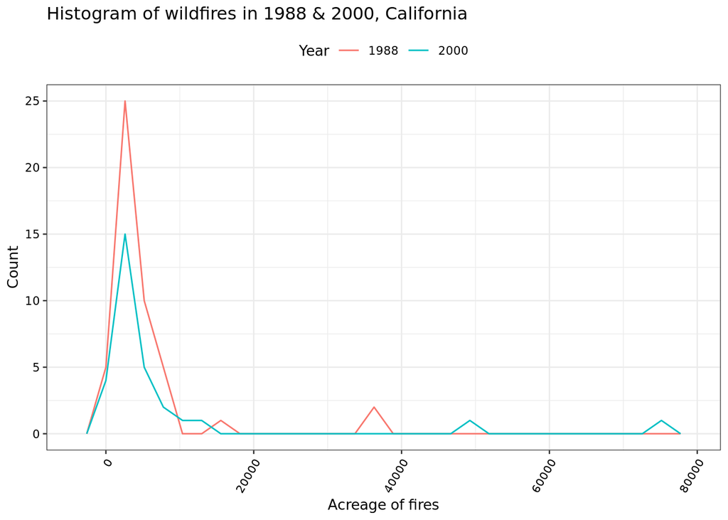

```r
#data exploration

ggplot(California.Wildfires, aes(x = ACRES, color =as.factor(YEAR))) +
  geom_freqpoly() +
  labs(x='Acreage of fires', y='Count', color='Year',
       title="Histogram of wildfires in 1988 & 2000, California")
```

**Figure 1**: Figure showing histogram of large wildfires in 1988 and 2000, California

We also created a map to show the locations of each of the fires for both the years within the state. The purple icons represent fires that burned in 1988 while the yellow icons represent fires that burned in 2000.

```r
#exploratory spatial plots
California.Wildfires.sf <- California.Wildfires %>%
  st_as_sf(coords=c('LONGITUDE', 'LATITUDE'), crs=4269)
```

```r
mapview(California.Wildfires.sf, zcol="YEAR")
```

[interactive chart not shown]

**Figure 2**: Map of location of large wildfires in California in 1988 and 2000

```r
# We want to only include wildfires, so we need to wrangle the data using the filter() function.

Wildfire_data <- Fire_data %>%
  filter(FIRE_TYPE == "Wildfire")

# We want to figure out which two states have the most wildfires

Count_per_state <- Wildfire_data %>%
  count(STATE)
```

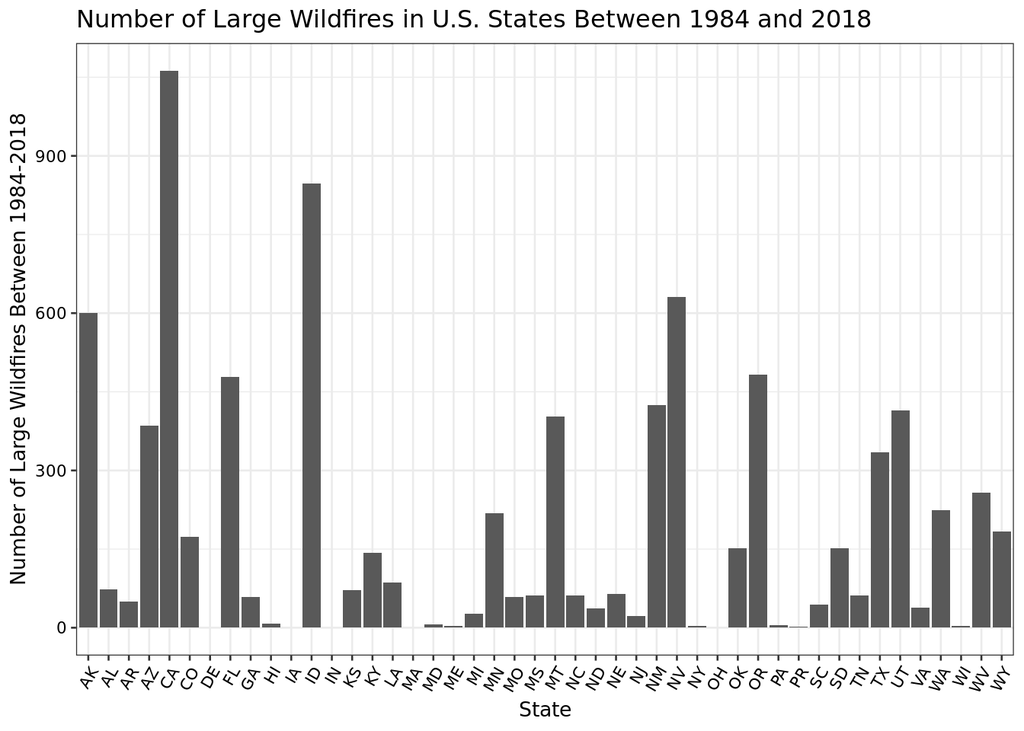

```r
# To view the amount of large wildfires for each space we can use ggplot() and within ggplot, the geom_bar() function.

Wildfires_state_plot <- ggplot(Wildfire_data) +
  geom_bar(aes(x=STATE)) +
  theme(axis.text.x=element_text(angle = 60, hjust = 1)) +
  xlab("State") +
  ylab("Number of Large Wildfires Between 1984-2018") +
  labs(title = "Number of Large Wildfires in U.S. States Between 1984 and 2018" )
print(Wildfires_state_plot)
```

```r
# Now knowing that California, Idaho, and Nevada have the most wildfire occurrences, we can filter the data to only include July and August fires for those three states using the pipe function %>%.

States_Wildfire_data <- Wildfire_data %>%
  filter(STATE == "CA" | STATE == "NV" | STATE == "ID")

# Now we need to wrangle the data, to get the mean wildfire sizes (acres) for the states with the most occurrences.

Mean_wildfire_size_state <- States_Wildfire_data %>%
  group_by(STATE, YEAR) %>%
  summarise(Mean_wildfire_size = mean(ACRES))
```

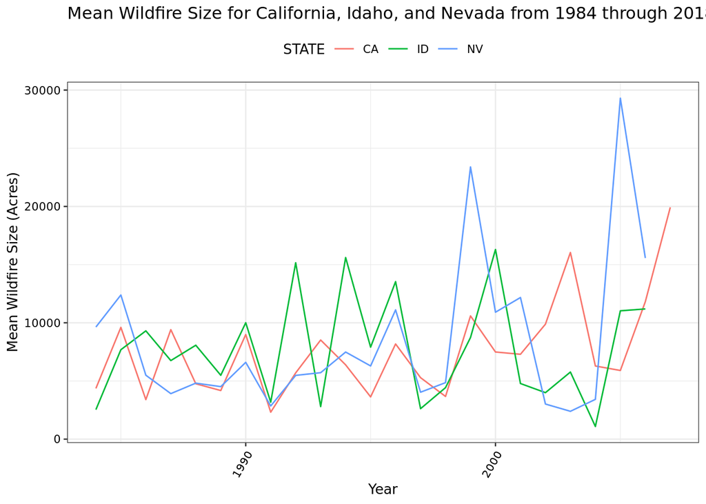

```r
# Using the mean wildfire dataset, we can plot the mean fire sizes data for each year. This will give us the line graph of each states mean wildfire sizes and how they have changed over the years.

mean_firesize_plot <- ggplot(Mean_wildfire_size_state, aes(x = YEAR, y = Mean_wildfire_size, color = STATE)) +
  geom_line() +
  xlab("Year") +
  ylab("Mean Wildfire Size (Acres)") +
  labs(title = "Mean Wildfire Size for California, Idaho, and Nevada from 1984 through 2018")
print(mean_firesize_plot)
```

**Question 3 Exploratory Analysis:**

```r
summary(Fire_data)
```

```
##     OBJECTID         ACRES           STATE            FIRE_NAME
##  Min.   :    1   Min.   :   500   Length:11999       Length:11999
##  1st Qu.: 3000   1st Qu.:  1264   Class :character   Class :character
##  Median : 6000   Median :  2196   Mode  :character   Mode  :character
##  Mean   : 6000   Mean   :  7598
##  3rd Qu.: 9000   3rd Qu.:  5027
##  Max.   :11999   Max.   :593364
##       YEAR        STARTMONTH        STARTDAY     FIRE_TYPE
##  Min.   :1984   Min.   : 1.000   Min.   : 1.0   Length:11999
##  1st Qu.:1992   1st Qu.: 4.000   1st Qu.: 7.0   Class :character
##  Median :1999   Median : 7.000   Median :15.0   Mode  :character
##  Mean   :1997   Mean   : 6.296   Mean   :15.3
##  3rd Qu.:2004   3rd Qu.: 8.000   3rd Qu.:23.0
##  Max.   :2007   Max.   :12.000   Max.   :31.0
##     LATITUDE       LONGITUDE
##  Min.   :17.96   Min.   :-165.88
##  1st Qu.:32.78   1st Qu.:-116.62
##  Median :37.31   Median :-107.21
##  Mean   :38.45   Mean   :-104.53
##  3rd Qu.:42.86   3rd Qu.: -86.16
##  Max.   :69.47   Max.   : -66.13
```

```r
#Wrangling dataset for California fires only
all_cal_fires <- Fire_data %>%
  filter(STATE=="CA")
summary(all_cal_fires)
```

```
##     OBJECTID         ACRES           STATE            FIRE_NAME
##  Min.   :   21   Min.   :  1001   Length:1250        Length:1250
##  1st Qu.: 2040   1st Qu.:  1512   Class :character   Class :character
##  Median : 4528   Median :  2470   Mode  :character   Mode  :character
##  Mean   : 5001   Mean   :  7567
##  3rd Qu.: 7914   3rd Qu.:  5502
##  Max.   :11908   Max.   :268362
##       YEAR        STARTMONTH        STARTDAY     FIRE_TYPE
##  Min.   :1984   Min.   : 1.000   Min.   : 1.0   Length:1250
##  1st Qu.:1989   1st Qu.: 6.000   1st Qu.: 8.0   Class :character
##  Median :1996   Median : 8.000   Median :17.0   Mode  :character
##  Mean   :1996   Mean   : 7.513   Mean   :16.6
##  3rd Qu.:2002   3rd Qu.: 9.000   3rd Qu.:25.0
##  Max.   :2007   Max.   :12.000   Max.   :31.0
##     LATITUDE       LONGITUDE
##  Min.   :32.58   Min.   :-124.2
##  1st Qu.:34.54   1st Qu.:-121.3
##  Median :36.31   Median :-119.9
##  Mean   :36.84   Mean   :-119.8
##  3rd Qu.:39.16   3rd Qu.:-118.4
##  Max.   :42.00   Max.   :-114.5
```

```r
cal_fires <- all_cal_fires %>%
  filter(FIRE_TYPE=="Wildfire" | FIRE_TYPE=="Prescribed Fire" | FIRE_TYPE=="Wildland Fire Use")
summary(cal_fires)
```

```
##     OBJECTID         ACRES           STATE            FIRE_NAME
##  Min.   :   21   Min.   :  1001   Length:1195        Length:1195
##  1st Qu.: 2050   1st Qu.:  1527   Class :character   Class :character
##  Median : 4538   Median :  2508   Mode  :character   Mode  :character
##  Mean   : 5075   Mean   :  7794
##  3rd Qu.: 7918   3rd Qu.:  5656
##  Max.   :11908   Max.   :268362
##       YEAR        STARTMONTH        STARTDAY      FIRE_TYPE
##  Min.   :1984   Min.   : 1.000   Min.   : 1.00   Length:1195
##  1st Qu.:1989   1st Qu.: 6.500   1st Qu.: 8.00   Class :character
##  Median :1996   Median : 8.000   Median :17.00   Mode  :character
##  Mean   :1996   Mean   : 7.541   Mean   :16.58
##  3rd Qu.:2002   3rd Qu.: 9.000   3rd Qu.:25.00
##  Max.   :2007   Max.   :12.000   Max.   :31.00
##     LATITUDE       LONGITUDE
##  Min.   :32.58   Min.   :-124.2
##  1st Qu.:34.49   1st Qu.:-121.3
##  Median :36.31   Median :-119.9
##  Mean   :36.82   Mean   :-119.8
##  3rd Qu.:39.14   3rd Qu.:-118.4
##  Max.   :42.00   Max.   :-114.5
```

```r
#Wrangling Wildfire dataset

wildfires_ca <- cal_fires %>%
  filter(FIRE_TYPE=="Wildfire")

wildfires_mean <-
  wildfires_ca %>%
  group_by(YEAR) %>%
  summarize(Mean_fires = mean(ACRES))
```

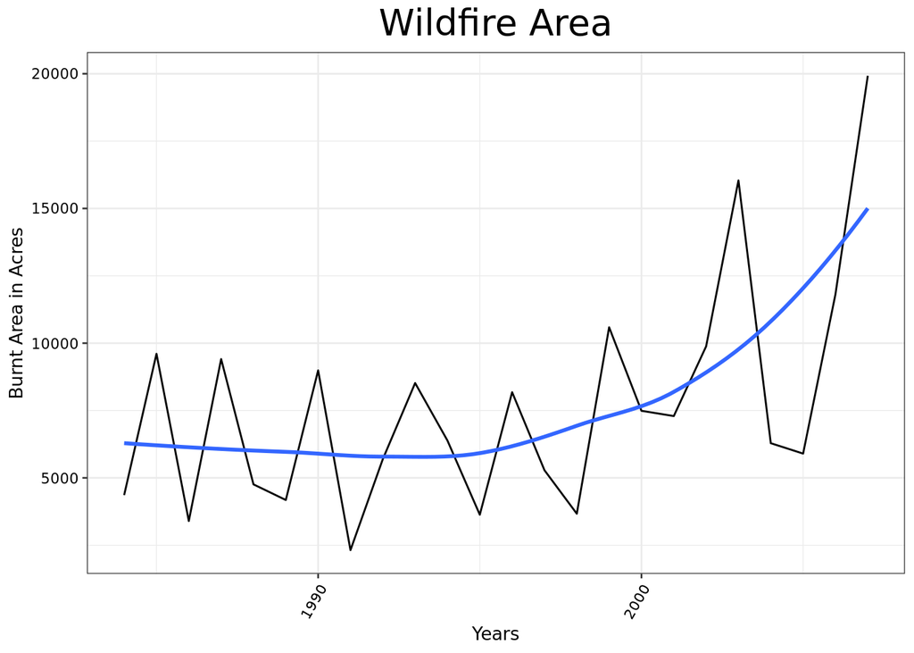

```r
#Plotting Wildfire Fires 1984-2007

wildfire_plot <-
  ggplot(wildfires_mean, aes(x = YEAR, y = Mean_fires)) +
  geom_line() +
  geom_smooth(method="loess",se=FALSE) +
  labs(title = "Wildfire Area",
       y="Burnt Area in Acres",
       x="Years") +
  theme(plot.title = element_text(size = 20))+
  theme(plot.title = element_text(hjust = 0.5))

print(wildfire_plot)
```

```r
#Wrangling Prescribed fire dataset

prescribed_fires_ca <- cal_fires %>%
  filter(FIRE_TYPE=="Prescribed Fire")

prescribed_fires_mean <-
  prescribed_fires_ca %>%
  group_by(YEAR) %>%
  summarize(Mean_fires = mean(ACRES))
```

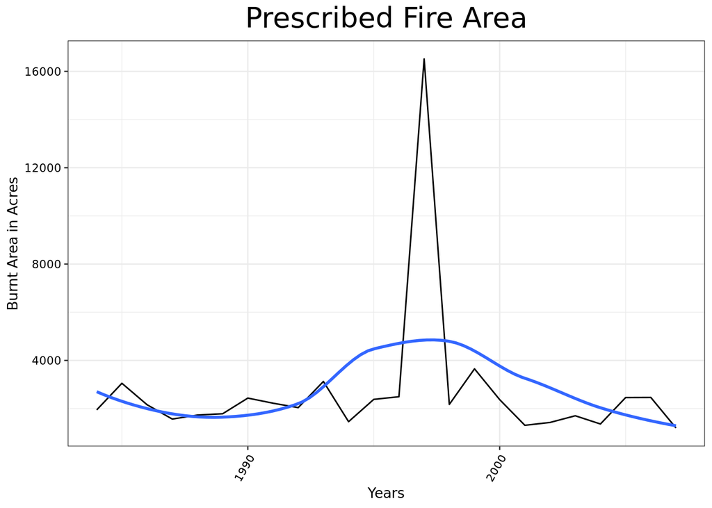

```r
#Plotting Prescribed Fires 1984-2007

prescribed_fire_plot <-
  ggplot(prescribed_fires_mean, aes(x = YEAR, y = Mean_fires)) +
  geom_line() +
  geom_smooth(method="loess",se=FALSE) +
  labs(title = "Prescribed Fire Area",
       y="Burnt Area in Acres",
       x="Years") +
  theme(plot.title = element_text(size = 20))+
  theme(plot.title = element_text(hjust = 0.5))

print(prescribed_fire_plot)
```

```r
#Wrangling Wildland Use Fire Dataset

wildland_fires_ca <- cal_fires %>%
filter(FIRE_TYPE=="Wildland Fire Use")

wildland_fires_mean <-
  wildland_fires_ca %>%
  group_by(YEAR) %>%
  summarize(Mean_fires = mean(ACRES))
```

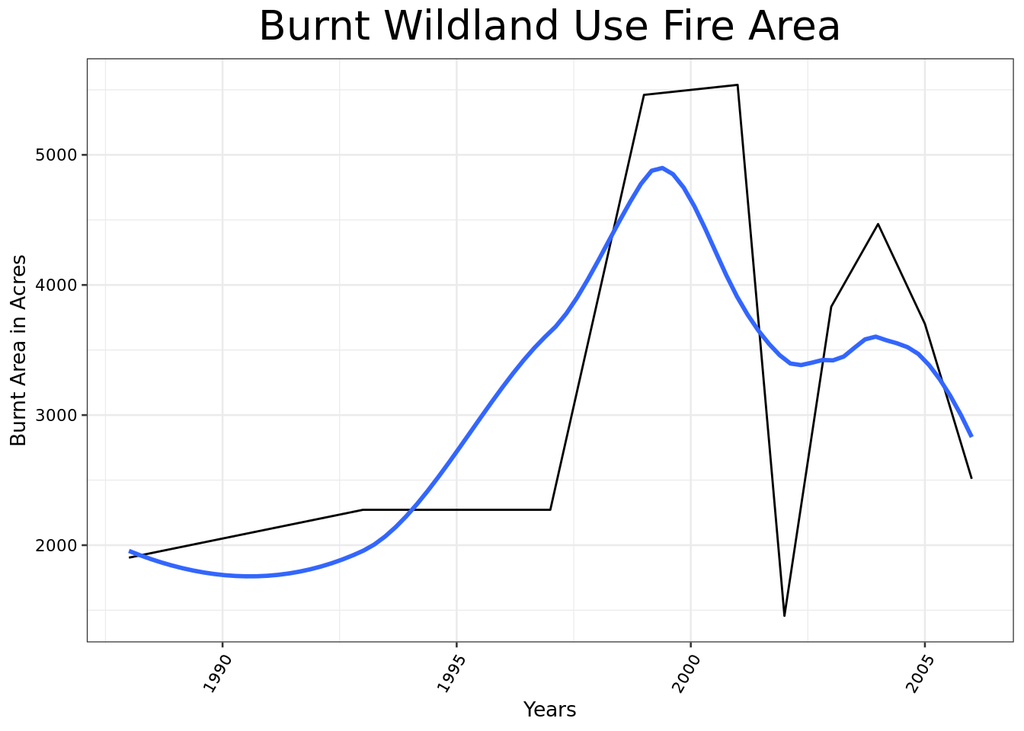

```r
#Plotting Wildland Fires 1984-2007

#We reject the the Prescribed and Wildland Fire data sets. Their time series cannot be plotted since there are huge gaps and great inconsistency in data and thus a significant trend or pattern cannot be deduced.

wildland_fire_plot <-
  ggplot(wildland_fires_mean, aes(x = YEAR, y = Mean_fires)) +
  geom_line() +
  geom_smooth(method="loess",se=FALSE) +
  labs(title = "Burnt Wildland Use Fire Area",
       y="Burnt Area in Acres",
       x="Years")+
  theme(plot.title = element_text(size = 20))+
  theme(plot.title = element_text(hjust = 0.5))

print(wildland_fire_plot)
```

**Figure 7**: Burnt Wildland Use Fire Area from 1988-2007 in California

# Analysis

**Question 1: Do the mean sizes of large wildfires in California differ between 1988 and 2000?**

To test whether the mean sizes of large wildfires in California differ between 1988 and 2000, we ran a t-sample t test to test the hypothesis.

H0 (null hypothesis): Means between both years are equal H1 (alternative hypothesis): Means between both years are not equal

From the two-sample test, we obtained a p-value of 0.3754, which was more than 0.05. This meant that we accept the null hypothesis that the means were statistically equal for both years.

```r
#running two sample t test and printing the result of the test
Twosamp.ttest <- t.test(California.Wildfires$ACRES ~ California.Wildfires$YEAR)
Twosamp.ttest
```

```
##
##  Welch Two Sample t-test
##
## data:  California.Wildfires$ACRES by California.Wildfires$YEAR
## t = -0.8974, df = 36.471, p-value = 0.3754
## alternative hypothesis: true difference in means between group 1988 and group 2000 is not equal to 0
## 95 percent confidence interval:
##  -8898.834  3437.684
## sample estimates:
## mean in group 1988 mean in group 2000
##           4758.792           7489.367
```

**Question 2: Is there a difference between large wildfire sizes in the 3 states with the most large wildfire occurrences? (California, Idaho, and Nevada)**

To test if there are differences in the large wildfire sizes in these three states, we ran an analysis of variance using an ANOVA test.

H0 (null hypothesis): There is no difference between large wildfire sizes in the 3 states with the most large wildfire occurrences (California, Idaho, and Nevada). H1 (alternative hypothesis): There is a difference between large wildfire sizes in the 3 states with the most large wildfire occurrences (California, Idaho, and Nevada).

We first ran an ANOVA, and the result of our ANOVA was a p-value of 0.00274, which would lead us to reject the null hypothesis. The next test we ran was the linear model, which gave us the results that California and Nevada are statistically different (p-value = 0.000617), but Idaho is not. This is also confirmed in the Tukey HSD test, which you can see the results of in Figure 8.

```r
# Run the first ANOVA using the aov() function

FireSize_ANOVA <- aov(data = States_Wildfire_data, ACRES ~ STATE)
summary(FireSize_ANOVA)
```

```
##               Df    Sum Sq   Mean Sq F value  Pr(>F)
## STATE          2 6.583e+09 3.291e+09   5.915 0.00274 **
## Residuals   2537 1.412e+12 5.565e+08
## ---
## Signif. codes:  0 '***' 0.001 '**' 0.01 '*' 0.05 '.' 0.1 ' ' 1
```

```r
# Run the same ANOVA using the the lm() function to get more details

FireSize_ANOVA2 <- lm(data = States_Wildfire_data, ACRES ~ STATE)
summary(FireSize_ANOVA2)
```

```
##
## Call:
## lm(formula = ACRES ~ STATE, data = States_Wildfire_data)
##
## Residuals:
##    Min     1Q Median     3Q    Max
## -11480  -7605  -6286  -2056 314673
##
## Coefficients:
##             Estimate Std. Error t value Pr(>|t|)
## (Intercept)   8418.1      723.9  11.629  < 2e-16 ***
## STATEID       1243.7     1086.7   1.144 0.252555
## STATENV       4065.1     1185.7   3.428 0.000617 ***
## ---
## Signif. codes:  0 '***' 0.001 '**' 0.01 '*' 0.05 '.' 0.1 ' ' 1
##
## Residual standard error: 23590 on 2537 degrees of freedom
## Multiple R-squared:  0.004641,   Adjusted R-squared:  0.003856
## F-statistic: 5.915 on 2 and 2537 DF,  p-value: 0.002737
```

```r
# Use the HSD.test to extract the groupings for pairwise relationships.

FireSize_groups <- HSD.test(FireSize_ANOVA, "STATE", group = TRUE)
FireSize_groups
```

```
## $statistics
##     MSerror   Df     Mean       CV
##   556464780 2537 9842.708 239.6648
##
## $parameters
##    test name.t ntr StudentizedRange alpha
##   Tukey  STATE   3         3.316443  0.05
##
## $means
##        ACRES      std    r  Min    Max    Q25  Q50     Q75
## CA  8418.112 19718.89 1062 1001 268362 1546.5 2711  6357.5
## ID  9661.784 24318.96  847 1000 271361 1684.0 3082  7523.5
## NV 12483.222 28139.77  631 1003 327156 1975.5 3958 10644.5
##
## $comparison
## NULL
##
## $groups
##        ACRES groups
## NV 12483.222      a
## ID  9661.784     ab
## CA  8418.112      b
##
## attr(,"class")
## [1] "group"
```

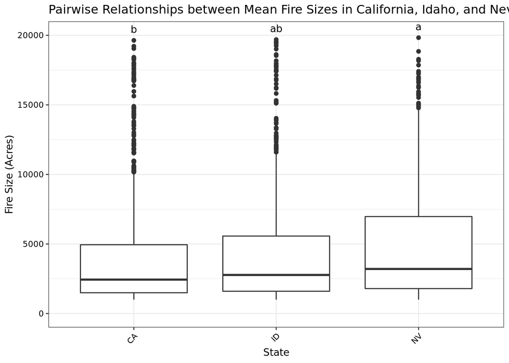

```r
# Plot the groupings using ggplot()

FireSize_plot <- ggplot(States_Wildfire_data, aes(x = STATE, y = ACRES)) +
  geom_boxplot() +
  theme(axis.text.x = element_text(angle = 45, hjust = 1)) +
  stat_summary(geom = "text", fun = max, vjust = -1, size = 3.5,
               label = c("b", "ab", "a")) +
  labs(x = "State", y = "Fire Size (Acres)", title = "Pairwise Relationships between Mean Fire Sizes in California, Idaho, and Nevada") +
  ylim(0, 20000)
print(FireSize_plot)
```

**Figure 8**: Pairwise relationships between California, Idaho, and Nevada wildfire sizes. Groupings found using the Tukey’s HSD test.

**Question 3: Is there a trend in large fire occurrences in California from 1984 to 2007? What is the trend in wildfire, prescribed fires and wildland fire use over the same years?**